# Rossmann by Buddhi

## Fastai Implementation of Kaggle Competition: Rossmann Store Sales 3rd Place Winner

In this post, I shall talk about the implementation of the Rossmann Kaggle competition 3rd place winning solution. It was implemented by Cheng Guo as part of team Neokami Inc. Unlike most other solution which employed XGBoost, he implemented a neural network taking advantage of a method called Entity Embedding. The proposed solution compromised of minimal feature engineering.

We learnt his solution as part the Fastai Deep learning 1 course where we were learnt how to solve structured data problems using the fastai library. The fastai libraries wraps around pandas, numpy, pytorch and other libraries, but these three being the main ones for structurd neural networks.

Data provided by the Kaggle competition were:

```
1. train.csv - Historical data including sales
2. test.csv - Historical data excluding sales
3. store.csv - Supplemental information about the stores
```

The competition allowed participants to use external data in the condition that the data used was share with other. Guo used the following extra dataset which were provided by other participants.

```
1. store_states.csv - Maps stores to the state its in
2. state_name.csv - Maps state abbreviations to names
3. googletrend.csv - Google trends by Bundesland for each state
4. weather.csv - Weather conditions for each states
```

To start off with, lets import the required fastai libraries.

```
1. fastai.structured - Fastai library implementation along side with pandas for structured data implementations. This library is taught in the Machine Learning course.
2. fastai.column_data - Fastai implementation along side with PyTorch for columnar structured data neural networks.
```

```python
from fastai.structured import *
from fastai.column_data import *
np.set_printoptions(threshold=50, edgeitems=20)

PATH='data/rossmann/'
PATH_TMP = 'data/rossmann/tmp/'
```

Firstly, lets open the tables and have a look at the data in them.

```python
def display_all(df):
    with pd.option_context("display.max_rows", 1000, "display.max_columns", 1000):
        display(df)
```

```python
table_names = ['train', 'store', 'store_states', 'state_names',
               'googletrend', 'weather', 'test']
```

```python
tables = [pd.read_csv(f'{PATH}{fnames}.csv', low_memory=False)
         for fnames in table_names]
```

```python
train, store, store_states, state_names, googletrend, weather, test = tables
```

```python
from IPython.display import HTML, display
```

```python
for i in range(len(tables)):
    print(table_names[i])
    display(tables[i].head())
```

```
train
```

|  | Store | DayOfWeek | Date | Sales | Customers | Open | Promo | StateHoliday | SchoolHoliday |
| --- | --- | --- | --- | --- | --- | --- | --- | --- | --- |
| 0 | 1 | 5 | 2015-07-31 | 5263 | 555 | 1 | 1 | 0 | 1 |
| 1 | 2 | 5 | 2015-07-31 | 6064 | 625 | 1 | 1 | 0 | 1 |
| 2 | 3 | 5 | 2015-07-31 | 8314 | 821 | 1 | 1 | 0 | 1 |
| 3 | 4 | 5 | 2015-07-31 | 13995 | 1498 | 1 | 1 | 0 | 1 |
| 4 | 5 | 5 | 2015-07-31 | 4822 | 559 | 1 | 1 | 0 | 1 |

```
store
```

|  | Store | StoreType | Assortment | CompetitionDistance | CompetitionOpenSinceMonth | CompetitionOpenSinceYear | Promo2 | Promo2SinceWeek | Promo2SinceYear | PromoInterval |
| --- | --- | --- | --- | --- | --- | --- | --- | --- | --- | --- |
| 0 | 1 | c | a | 1270.0 | 9.0 | 2008.0 | 0 | NaN | NaN | NaN |
| 1 | 2 | a | a | 570.0 | 11.0 | 2007.0 | 1 | 13.0 | 2010.0 | Jan,Apr,Jul,Oct |
| 2 | 3 | a | a | 14130.0 | 12.0 | 2006.0 | 1 | 14.0 | 2011.0 | Jan,Apr,Jul,Oct |
| 3 | 4 | c | c | 620.0 | 9.0 | 2009.0 | 0 | NaN | NaN | NaN |
| 4 | 5 | a | a | 29910.0 | 4.0 | 2015.0 | 0 | NaN | NaN | NaN |

```
store_states
```

|  | Store | State |
| --- | --- | --- |
| 0 | 1 | HE |
| 1 | 2 | TH |
| 2 | 3 | NW |
| 3 | 4 | BE |
| 4 | 5 | SN |

```
state_names
```

|  | StateName | State |
| --- | --- | --- |
| 0 | BadenWuerttemberg | BW |
| 1 | Bayern | BY |
| 2 | Berlin | BE |
| 3 | Brandenburg | BB |
| 4 | Bremen | HB |

```
googletrend
```

|  | file | week | trend |
| --- | --- | --- | --- |
| 0 | Rossmann_DE_SN | 2012-12-02 - 2012-12-08 | 96 |
| 1 | Rossmann_DE_SN | 2012-12-09 - 2012-12-15 | 95 |
| 2 | Rossmann_DE_SN | 2012-12-16 - 2012-12-22 | 91 |
| 3 | Rossmann_DE_SN | 2012-12-23 - 2012-12-29 | 48 |
| 4 | Rossmann_DE_SN | 2012-12-30 - 2013-01-05 | 67 |

```
weather
```

|  | file | Date | Max_TemperatureC | Mean_TemperatureC | Min_TemperatureC | Dew_PointC | MeanDew_PointC | Min_DewpointC | Max_Humidity | Mean_Humidity | ... | Max_VisibilityKm | Mean_VisibilityKm | Min_VisibilitykM | Max_Wind_SpeedKm_h | Mean_Wind_SpeedKm_h | Max_Gust_SpeedKm_h | Precipitationmm | CloudCover | Events | WindDirDegrees |
| --- | --- | --- | --- | --- | --- | --- | --- | --- | --- | --- | --- | --- | --- | --- | --- | --- | --- | --- | --- | --- | --- |
| 0 | NordrheinWestfalen | 2013-01-01 | 8 | 4 | 2 | 7 | 5 | 1 | 94 | 87 | ... | 31.0 | 12.0 | 4.0 | 39 | 26 | 58.0 | 5.08 | 6.0 | Rain | 215 |
| 1 | NordrheinWestfalen | 2013-01-02 | 7 | 4 | 1 | 5 | 3 | 2 | 93 | 85 | ... | 31.0 | 14.0 | 10.0 | 24 | 16 | NaN | 0.00 | 6.0 | Rain | 225 |
| 2 | NordrheinWestfalen | 2013-01-03 | 11 | 8 | 6 | 10 | 8 | 4 | 100 | 93 | ... | 31.0 | 8.0 | 2.0 | 26 | 21 | NaN | 1.02 | 7.0 | Rain | 240 |
| 3 | NordrheinWestfalen | 2013-01-04 | 9 | 9 | 8 | 9 | 9 | 8 | 100 | 94 | ... | 11.0 | 5.0 | 2.0 | 23 | 14 | NaN | 0.25 | 7.0 | Rain | 263 |
| 4 | NordrheinWestfalen | 2013-01-05 | 8 | 8 | 7 | 8 | 7 | 6 | 100 | 94 | ... | 10.0 | 6.0 | 3.0 | 16 | 10 | NaN | 0.00 | 7.0 | Rain | 268 |

5 rows × 24 columns

```
test
```

|  | Id | Store | DayOfWeek | Date | Open | Promo | StateHoliday | SchoolHoliday |
| --- | --- | --- | --- | --- | --- | --- | --- | --- |
| 0 | 1 | 1 | 4 | 2015-09-17 | 1.0 | 1 | 0 | 0 |
| 1 | 2 | 3 | 4 | 2015-09-17 | 1.0 | 1 | 0 | 0 |
| 2 | 3 | 7 | 4 | 2015-09-17 | 1.0 | 1 | 0 | 0 |
| 3 | 4 | 8 | 4 | 2015-09-17 | 1.0 | 1 | 0 | 0 |
| 4 | 5 | 9 | 4 | 2015-09-17 | 1.0 | 1 | 0 | 0 |

```
store.csv - Describes the store type, what they sell and information regarding their competitions.
train.csv - For a given date, the total sales, if a promotion was on, and whether that day was either a state or school holiday.
weather.csv - Describes the state and its weather condition on a given date.
state_names.csv - Defines each states abbriviations.
store_state.csv - States where each store is located.
test.csv - Similar to the training dataset provided but excluding sales which is required to be predicted for the competiton.
googletrend.csv - Specifies the trend for each week for Rossmann stores in their respective states.
```

Below, we'll open each table and examin them statistically as it will give us an idea of what the data looks like

```python
for i in range(len(tables)):
    print(table_names[i])
    display(DataFrameSummary(tables[i]).summary())
```

```
train
```

|  | Store | DayOfWeek | Date | Sales | Customers | Open | Promo | StateHoliday | SchoolHoliday |
| --- | --- | --- | --- | --- | --- | --- | --- | --- | --- |
| count | 1.01721e+06 | 1.01721e+06 | NaN | 1.01721e+06 | 1.01721e+06 | 1.01721e+06 | 1.01721e+06 | NaN | 1.01721e+06 |
| mean | 558.43 | 3.99834 | NaN | 5773.82 | 633.146 | 0.830107 | 0.381515 | NaN | 0.178647 |
| std | 321.909 | 1.99739 | NaN | 3849.93 | 464.412 | 0.375539 | 0.485759 | NaN | 0.383056 |
| min | 1 | 1 | NaN | 0 | 0 | 0 | 0 | NaN | 0 |
| 25% | 280 | 2 | NaN | 3727 | 405 | 1 | 0 | NaN | 0 |
| 50% | 558 | 4 | NaN | 5744 | 609 | 1 | 0 | NaN | 0 |
| 75% | 838 | 6 | NaN | 7856 | 837 | 1 | 1 | NaN | 0 |
| max | 1115 | 7 | NaN | 41551 | 7388 | 1 | 1 | NaN | 1 |
| counts | 1017209 | 1017209 | 1017209 | 1017209 | 1017209 | 1017209 | 1017209 | 1017209 | 1017209 |
| uniques | 1115 | 7 | 942 | 21734 | 4086 | 2 | 2 | 4 | 2 |
| missing | 0 | 0 | 0 | 0 | 0 | 0 | 0 | 0 | 0 |
| missing_perc | 0% | 0% | 0% | 0% | 0% | 0% | 0% | 0% | 0% |
| types | numeric | numeric | categorical | numeric | numeric | bool | bool | categorical | bool |

```
store
```

|  | Store | StoreType | Assortment | CompetitionDistance | CompetitionOpenSinceMonth | CompetitionOpenSinceYear | Promo2 | Promo2SinceWeek | Promo2SinceYear | PromoInterval |
| --- | --- | --- | --- | --- | --- | --- | --- | --- | --- | --- |
| count | 1115 | NaN | NaN | 1112 | 761 | 761 | 1115 | 571 | 571 | NaN |
| mean | 558 | NaN | NaN | 5404.9 | 7.2247 | 2008.67 | 0.512108 | 23.5954 | 2011.76 | NaN |
| std | 322.017 | NaN | NaN | 7663.17 | 3.21235 | 6.19598 | 0.500078 | 14.142 | 1.67494 | NaN |
| min | 1 | NaN | NaN | 20 | 1 | 1900 | 0 | 1 | 2009 | NaN |
| 25% | 279.5 | NaN | NaN | 717.5 | 4 | 2006 | 0 | 13 | 2011 | NaN |
| 50% | 558 | NaN | NaN | 2325 | 8 | 2010 | 1 | 22 | 2012 | NaN |
| 75% | 836.5 | NaN | NaN | 6882.5 | 10 | 2013 | 1 | 37 | 2013 | NaN |
| max | 1115 | NaN | NaN | 75860 | 12 | 2015 | 1 | 50 | 2015 | NaN |
| counts | 1115 | 1115 | 1115 | 1112 | 761 | 761 | 1115 | 571 | 571 | 571 |
| uniques | 1115 | 4 | 3 | 654 | 12 | 23 | 2 | 24 | 7 | 3 |
| missing | 0 | 0 | 0 | 3 | 354 | 354 | 0 | 544 | 544 | 544 |
| missing_perc | 0% | 0% | 0% | 0.27% | 31.75% | 31.75% | 0% | 48.79% | 48.79% | 48.79% |
| types | numeric | categorical | categorical | numeric | numeric | numeric | bool | numeric | numeric | categorical |

```
store_states
```

|  | Store | State |
| --- | --- | --- |
| count | 1115 | NaN |
| mean | 558 | NaN |
| std | 322.017 | NaN |
| min | 1 | NaN |
| 25% | 279.5 | NaN |
| 50% | 558 | NaN |
| 75% | 836.5 | NaN |
| max | 1115 | NaN |
| counts | 1115 | 1115 |
| uniques | 1115 | 12 |
| missing | 0 | 0 |
| missing_perc | 0% | 0% |
| types | numeric | categorical |

```
state_names
```

|  | StateName | State |
| --- | --- | --- |
| count | 16 | 16 |
| unique | 16 | 16 |
| top | RheinlandPfalz | ST |
| freq | 1 | 1 |
| counts | 16 | 16 |
| uniques | 16 | 16 |
| missing | 0 | 0 |
| missing_perc | 0% | 0% |
| types | unique | unique |

```
googletrend
```

|  | file | week | trend |
| --- | --- | --- | --- |
| count | NaN | NaN | 2072 |
| mean | NaN | NaN | 63.8142 |
| std | NaN | NaN | 12.6502 |
| min | NaN | NaN | 0 |
| 25% | NaN | NaN | 55 |
| 50% | NaN | NaN | 64 |
| 75% | NaN | NaN | 72 |
| max | NaN | NaN | 100 |
| counts | 2072 | 2072 | 2072 |
| uniques | 14 | 148 | 68 |
| missing | 0 | 0 | 0 |
| missing_perc | 0% | 0% | 0% |
| types | categorical | categorical | numeric |

```
weather
```

|  | file | Date | Max_TemperatureC | Mean_TemperatureC | Min_TemperatureC | Dew_PointC | MeanDew_PointC | Min_DewpointC | Max_Humidity | Mean_Humidity | ... | Max_VisibilityKm | Mean_VisibilityKm | Min_VisibilitykM | Max_Wind_SpeedKm_h | Mean_Wind_SpeedKm_h | Max_Gust_SpeedKm_h | Precipitationmm | CloudCover | Events | WindDirDegrees |
| --- | --- | --- | --- | --- | --- | --- | --- | --- | --- | --- | --- | --- | --- | --- | --- | --- | --- | --- | --- | --- | --- |
| count | NaN | NaN | 15840 | 15840 | 15840 | 15840 | 15840 | 15840 | 15840 | 15840 | ... | 15459 | 15459 | 15459 | 15840 | 15840 | 3604 | 15840 | 14667 | NaN | 15840 |
| mean | NaN | NaN | 14.6441 | 10.389 | 6.19899 | 8.58782 | 6.20581 | 3.62614 | 93.6596 | 74.2829 | ... | 24.0576 | 12.2398 | 7.02516 | 22.7666 | 11.9722 | 48.8643 | 0.831718 | 5.55131 | NaN | 175.897 |
| std | NaN | NaN | 8.64601 | 7.37926 | 6.52639 | 6.24478 | 6.08677 | 6.12839 | 7.67853 | 13.4866 | ... | 8.9768 | 5.06794 | 4.9806 | 8.98862 | 5.87284 | 13.027 | 2.51351 | 1.68771 | NaN | 101.589 |
| min | NaN | NaN | -11 | -13 | -15 | -14 | -15 | -73 | 44 | 30 | ... | 0 | 0 | 0 | 3 | 2 | 21 | 0 | 0 | NaN | -1 |
| 25% | NaN | NaN | 8 | 4 | 1 | 4 | 2 | -1 | 90.75 | 65 | ... | 14 | 10 | 3 | 16 | 8 | 39 | 0 | 5 | NaN | 80 |
| 50% | NaN | NaN | 15 | 11 | 7 | 9 | 7 | 4 | 94 | 76 | ... | 31 | 11 | 7 | 21 | 11 | 48 | 0 | 6 | NaN | 202 |
| 75% | NaN | NaN | 21 | 16 | 11 | 13 | 11 | 8 | 100 | 85 | ... | 31 | 14 | 10 | 27 | 14 | 55 | 0.25 | 7 | NaN | 256 |
| max | NaN | NaN | 39 | 31 | 24 | 25 | 20 | 19 | 100 | 100 | ... | 31 | 31 | 31 | 101 | 53 | 111 | 58.93 | 8 | NaN | 360 |
| counts | 15840 | 15840 | 15840 | 15840 | 15840 | 15840 | 15840 | 15840 | 15840 | 15840 | ... | 15459 | 15459 | 15459 | 15840 | 15840 | 3604 | 15840 | 14667 | 11889 | 15840 |
| uniques | 16 | 990 | 51 | 45 | 40 | 40 | 36 | 40 | 53 | 71 | ... | 24 | 32 | 24 | 44 | 29 | 47 | 41 | 9 | 21 | 362 |
| missing | 0 | 0 | 0 | 0 | 0 | 0 | 0 | 0 | 0 | 0 | ... | 381 | 381 | 381 | 0 | 0 | 12236 | 0 | 1173 | 3951 | 0 |
| missing_perc | 0% | 0% | 0% | 0% | 0% | 0% | 0% | 0% | 0% | 0% | ... | 2.41% | 2.41% | 2.41% | 0% | 0% | 77.25% | 0% | 7.41% | 24.94% | 0% |
| types | categorical | categorical | numeric | numeric | numeric | numeric | numeric | numeric | numeric | numeric | ... | numeric | numeric | numeric | numeric | numeric | numeric | numeric | numeric | categorical | numeric |

13 rows × 24 columns

```
test
```

|  | Id | Store | DayOfWeek | Date | Open | Promo | StateHoliday | SchoolHoliday |
| --- | --- | --- | --- | --- | --- | --- | --- | --- |
| count | 41088 | 41088 | 41088 | NaN | 41077 | 41088 | NaN | 41088 |
| mean | 20544.5 | 555.9 | 3.97917 | NaN | 0.854322 | 0.395833 | NaN | 0.443487 |
| std | 11861.2 | 320.274 | 2.01548 | NaN | 0.352787 | 0.489035 | NaN | 0.496802 |
| min | 1 | 1 | 1 | NaN | 0 | 0 | NaN | 0 |
| 25% | 10272.8 | 279.75 | 2 | NaN | 1 | 0 | NaN | 0 |
| 50% | 20544.5 | 553.5 | 4 | NaN | 1 | 0 | NaN | 0 |
| 75% | 30816.2 | 832.25 | 6 | NaN | 1 | 1 | NaN | 1 |
| max | 41088 | 1115 | 7 | NaN | 1 | 1 | NaN | 1 |
| counts | 41088 | 41088 | 41088 | 41088 | 41077 | 41088 | 41088 | 41088 |
| uniques | 41088 | 856 | 7 | 48 | 2 | 2 | 2 | 2 |
| missing | 0 | 0 | 0 | 0 | 11 | 0 | 0 | 0 |
| missing_perc | 0% | 0% | 0% | 0% | 0.03% | 0% | 0% | 0% |
| types | numeric | numeric | numeric | categorical | bool | bool | bool | bool |

## Data Cleaning / Feature Engineering

To get a neural network to predict sales for the training dataset, we'll need to generate a single dataset. For this we'll need to clean the data provided in each table and combine them and apply some feature engineering to aid the neural network get better results.

As we clean the data and apply feature engineering, we'll keep joining the tables together to create a single data set. To start off with, we've identified from the tables above that in train.csv, StateHoliday is a categorical value compared to SchoolHoliday, so lets fix that

```python
train.StateHoliday = train.StateHoliday != '0'
test.StateHoliday = test.StateHoliday != '0'
```

```python
DataFrameSummary(train).summary()
```

|  | Store | DayOfWeek | Date | Sales | Customers | Open | Promo | StateHoliday | SchoolHoliday |
| --- | --- | --- | --- | --- | --- | --- | --- | --- | --- |
| count | 1.01721e+06 | 1.01721e+06 | NaN | 1.01721e+06 | 1.01721e+06 | 1.01721e+06 | 1.01721e+06 | NaN | 1.01721e+06 |
| mean | 558.43 | 3.99834 | NaN | 5773.82 | 633.146 | 0.830107 | 0.381515 | NaN | 0.178647 |
| std | 321.909 | 1.99739 | NaN | 3849.93 | 464.412 | 0.375539 | 0.485759 | NaN | 0.383056 |
| min | 1 | 1 | NaN | 0 | 0 | 0 | 0 | NaN | 0 |
| 25% | 280 | 2 | NaN | 3727 | 405 | 1 | 0 | NaN | 0 |
| 50% | 558 | 4 | NaN | 5744 | 609 | 1 | 0 | NaN | 0 |
| 75% | 838 | 6 | NaN | 7856 | 837 | 1 | 1 | NaN | 0 |
| max | 1115 | 7 | NaN | 41551 | 7388 | 1 | 1 | NaN | 1 |
| counts | 1017209 | 1017209 | 1017209 | 1017209 | 1017209 | 1017209 | 1017209 | 1017209 | 1017209 |
| uniques | 1115 | 7 | 942 | 21734 | 4086 | 2 | 2 | 2 | 2 |
| missing | 0 | 0 | 0 | 0 | 0 | 0 | 0 | 0 | 0 |
| missing_perc | 0% | 0% | 0% | 0% | 0% | 0% | 0% | 0% | 0% |
| types | numeric | numeric | categorical | numeric | numeric | bool | bool | bool | bool |

Lets, starts joining tables now. Pandas does this using a merge function, we will be applying a left join. We started off by creating a simple function to do this, it simply appends "_y" to duplicated columns on the right table.

```python
def join_df(left, right, left_on, right_on=None, suffix='_y'):
    if right_on is None: right_on = left_on
    return left.merge(right, how='left', left_on=left_on,
                      right_on=right_on, suffixes=("",suffix))
```

The first tables to be joined together would be the weather and state names

```python
weather = join_df(weather, state_names, "file", "StateName")
```

Then we'll look into the google trends table and clean it up a little bit before joining it with the rest

```python
display(googletrend.head())
```

|  | file | week | trend |
| --- | --- | --- | --- |
| 0 | Rossmann_DE_SN | 2012-12-02 - 2012-12-08 | 96 |
| 1 | Rossmann_DE_SN | 2012-12-09 - 2012-12-15 | 95 |
| 2 | Rossmann_DE_SN | 2012-12-16 - 2012-12-22 | 91 |
| 3 | Rossmann_DE_SN | 2012-12-23 - 2012-12-29 | 48 |
| 4 | Rossmann_DE_SN | 2012-12-30 - 2013-01-05 | 67 |

As it can be seen above, the googletrend data needs to be updated to match the format of the other tables.

```
1. A new column will be added called 'Date' which will be the first date under the week column.
2. The state name will be seperated from the column 'file' and put into a new column called 'State'.
3. The state NI is represented as HB,NI in the other tables, this needs to be matched as well.
```

```python
googletrend['Date'] = googletrend.week.str.split(' - ', expand=True)[0]
googletrend['State'] = googletrend.file.str.split('_', expand=True)[2]
googletrend.loc[googletrend.State=='NI', "State"] = 'HB,NI'
```

For the tables:

```
1. weather
2. googletrend
3. train
4. test
```

We are going to apply the Fastai datepart function. What this does is breaks the date into categorical values like day of week, month of year, is start of month, is end of month, is start of week, etc. This is a feature engineering method that has proven to be quite helpful in Machine learning datasets.

```python
add_datepart(weather, "Date", drop=False)
add_datepart(googletrend, "Date", drop=False)
add_datepart(train, "Date", drop=False)
add_datepart(test, "Date", drop=False)
```

The trend data has a special category for the whole of Germany called "Rossmann_DE". We shall put this into a different table entirely.

```python
trend_de = googletrend[googletrend.file == 'Rossmann_DE']
```

```python
store = join_df(store, store_states, "Store")
len(store[store.State.isnull()])
```

```
0
```

```python
joined = join_df(train, store, "Store")
joined_test = join_df(test, store, "Store")
len(joined[joined.StoreType.isnull()]),len(joined_test[joined_test.StoreType.isnull()])
```

```
(0, 0)
```

```python
joined = join_df(joined, googletrend, ["State","Year", "Week"])
joined_test = join_df(joined_test, googletrend,
                      ["State","Year", "Week"])
len(joined[joined.trend.isnull()]),len(joined_test[joined_test.trend.isnull()])
```

```
(0, 0)
```

```python
joined = joined.merge(trend_de, 'left', ["Year", "Week"],
                      suffixes=('', '_DE'))
joined_test = joined_test.merge(trend_de, 'left', ["Year", "Week"],
                                suffixes=('', '_DE'))
len(joined[joined.trend_DE.isnull()]),len(joined_test[joined_test.trend_DE.isnull()])
```

```
(0, 0)
```

```python
joined = join_df(joined, weather, ["State","Date"])
joined_test = join_df(joined_test, weather, ["State","Date"])
len(joined[joined.Mean_TemperatureC.isnull()]),len(joined_test[joined_test.Mean_TemperatureC.isnull()])
```

```
(0, 0)
```

We will go ahead and delete the columns that are duplicated, remember duplicated columns have the suffix "_y"

```python
for df in (joined, joined_test):
    for c in df.columns:
        if c.endswith('_y'):
            if c in df.columns:df.drop(c, inplace=True, axis=1)
```

Next, we remove some of the NA (not available) values from the data to prevent complications, this is how Pandas represent missing data values. Models usually have problems handling missing values. In these cases, we pick an arbitrary *signal value* that doesn't otherwise appear in the data

```python
for df in (joined, joined_test):
    for c in df.columns:
        if len(df[df[c].isnull()]): print(c)
```

```
CompetitionDistance
CompetitionOpenSinceMonth
CompetitionOpenSinceYear
Promo2SinceWeek
Promo2SinceYear
PromoInterval
State_DE
Max_VisibilityKm
Mean_VisibilityKm
Min_VisibilitykM
Max_Gust_SpeedKm_h
CloudCover
Events
Open
CompetitionDistance
CompetitionOpenSinceMonth
CompetitionOpenSinceYear
Promo2SinceWeek
Promo2SinceYear
PromoInterval
State_DE
Max_VisibilityKm
Mean_VisibilityKm
Min_VisibilitykM
Max_Gust_SpeedKm_h
CloudCover
Events
```

```python
columns = ['CompetitionOpenSinceMonth', 'CompetitionOpenSinceYear',
           'Promo2SinceWeek', 'Promo2SinceYear']
df = joined[columns]
df.describe()
```

|  | CompetitionOpenSinceMonth | CompetitionOpenSinceYear | Promo2SinceWeek | Promo2SinceYear |
| --- | --- | --- | --- | --- |
| count | 693861.000000 | 693861.000000 | 509178.000000 | 509178.000000 |
| mean | 7.222866 | 2008.690228 | 23.269093 | 2011.752774 |
| std | 3.211832 | 5.992644 | 14.095973 | 1.662870 |
| min | 1.000000 | 1900.000000 | 1.000000 | 2009.000000 |
| 25% | 4.000000 | 2006.000000 | 13.000000 | 2011.000000 |
| 50% | 8.000000 | 2010.000000 | 22.000000 | 2012.000000 |
| 75% | 10.000000 | 2013.000000 | 37.000000 | 2013.000000 |
| max | 12.000000 | 2015.000000 | 50.000000 | 2015.000000 |

We will use the minimum year value for "CompetitionOpenSinceYear" variable for both itself and the "Promo2SinceYear" variables.

```python
for df in (joined,joined_test):
    df['CompetitionOpenSinceYear'] = df.CompetitionOpenSinceYear.fillna(1900).astype(np.int32)
    df['CompetitionOpenSinceMonth'] = df.CompetitionOpenSinceMonth.fillna(1).astype(np.int32)
    df['Promo2SinceYear'] = df.Promo2SinceYear.fillna(1900).astype(np.int32)
    df['Promo2SinceWeek'] = df.Promo2SinceWeek.fillna(1).astype(np.int32)
```

We create a few features here:

```
1. CompetitionOpenSince - Date variable
2. CompetitionDaysOpen - Number of days
```

```python
for df in (joined, joined_test):
    df["CompetitionOpenSince"] = pd.to_datetime(
        dict(year=df.CompetitionOpenSinceYear,
            month=df.CompetitionOpenSinceMonth,
            day=15))
    df["CompetitionDaysOpen"] = df.Date.subtract(
        df.CompetitionOpenSince).dt.days
```

```python
df.CompetitionDaysOpen.describe()
```

```
count    41088.000000
mean     17123.353972
std      19352.430059
min        -14.000000
25%       1443.000000
50%       3634.000000
75%      42216.000000
max      42248.000000
Name: CompetitionDaysOpen, dtype: float64
```

Lets, clean CompetitionDaysOpen column

```python
for df in (joined, joined_test):
    df.loc[df.CompetitionDaysOpen<0, "CompetitionDaysOpen"] = 0
    df.loc[df.CompetitionOpenSinceYear<1990, "CompetitionDaysOpen"] = 0
```

Add column "CompetitionMonthsOpen" and set a maximum limit to 2 years. This is to limit number of unique categories

```python
for df in (joined, joined_test):
    df["CompetitionMonthsOpen"] = df["CompetitionDaysOpen"] // 30
    df.loc[df.CompetitionMonthsOpen>24, "CompetitionMonthsOpen"] = 24
joined.CompetitionMonthsOpen.unique()
```

```
array([24,  3, 19,  9,  0, 16, 17,  7, 15, 22, 11, 13,  2, 23, 12,  4, 10,  1, 14, 20,  8, 18,  6, 21,  5])
```

Apply same feature engineering to Promo dates.

```python
for df in (joined,joined_test):
    df["Promo2Since"] = pd.to_datetime(df.apply(lambda x: Week(
        x.Promo2SinceYear, x.Promo2SinceWeek).monday(), axis=1).astype(pd.datetime))
    df["Promo2Days"] = df.Date.subtract(df["Promo2Since"]).dt.days
```

```python
for df in (joined,joined_test):
    df.loc[df.Promo2Days<0, "Promo2Days"] = 0
    df.loc[df.Promo2SinceYear<1990, "Promo2Days"] = 0
    df["Promo2Weeks"] = df["Promo2Days"]//7
    df.loc[df.Promo2Weeks<0, "Promo2Weeks"] = 0
    df.loc[df.Promo2Weeks>25, "Promo2Weeks"] = 25
    df.Promo2Weeks.unique()
```

```python
display_all(joined.describe())
```

|  | Store | DayOfWeek | Sales | Customers | Open | Promo | SchoolHoliday | Year | Month | Week | Day | Dayofweek | Dayofyear | Elapsed | CompetitionDistance | CompetitionOpenSinceMonth | CompetitionOpenSinceYear | Promo2 | Promo2SinceWeek | Promo2SinceYear | trend | trend_DE | Month_DE | Day_DE | Dayofweek_DE | Dayofyear_DE | Elapsed_DE | Max_TemperatureC | Mean_TemperatureC | … |
| --- | --- | --- | --- | --- | --- | --- | --- | --- | --- | --- | --- | --- | --- | --- | --- | --- | --- | --- | --- | --- | --- | --- | --- | --- | --- | --- | --- | --- | --- | --- |
| count | 1.017209e+06 | 1.017209e+06 | 1.017209e+06 | 1.017209e+06 | 1.017209e+06 | 1.017209e+06 | 1.017209e+06 | 1.017209e+06 | 1.017209e+06 | 1.017209e+06 | 1.017209e+06 | 1.017209e+06 | 1.017209e+06 | 1.017209e+06 | 1.014567e+06 | 1.017209e+06 | 1.017209e+06 | 1.017209e+06 | 1.017209e+06 | 1.017209e+06 | 1.017209e+06 | 1.017209e+06 | 1.017209e+06 | 1.017209e+06 | 1017209.0 | 1.017209e+06 | 1.017209e+06 | 1.017209e+06 | 1.017209e+06 | … |
| mean | 5.584297e+02 | 3.998341e+00 | 5.773819e+03 | 6.331459e+02 | 8.301067e-01 | 3.815145e-01 | 1.786467e-01 | 2.013832e+03 | 5.846762e+00 | 2.361551e+01 | 1.570279e+01 | 2.998341e+00 | 1.622764e+02 | 1.397180e+09 | 5.430086e+03 | 5.244756e+00 | 1.974140e+03 | 5.005638e-01 | 1.214710e+01 | 1.955939e+03 | 6.521919e+01 | 6.623480e+01 | 5.891212e+00 | 1.556211e+01 | 6.0 | 1.634763e+02 | 1.397284e+09 | 1.432830e+01 | 1.007386e+01 | … |
| std | 3.219087e+02 | 1.997391e+00 | 3.849926e+03 | 4.644117e+02 | 3.755392e-01 | 4.857586e-01 | 3.830564e-01 | 7.773960e-01 | 3.326097e+00 | 1.443338e+01 | 8.787638e+00 | 1.997391e+00 | 1.016162e+02 | 2.371283e+07 | 7.715324e+03 | 3.928522e+00 | 5.085323e+01 | 4.999999e-01 | 1.494785e+01 | 5.588876e+01 | 1.133987e+01 | 9.618326e+00 | 3.308500e+00 | 8.802947e+00 | 0.0 | 1.012360e+02 | 2.375728e+07 | 8.464778e+00 | 7.239083e+00 | … |
| min | 1.000000e+00 | 1.000000e+00 | 0.000000e+00 | 0.000000e+00 | 0.000000e+00 | 0.000000e+00 | 0.000000e+00 | 2.013000e+03 | 1.000000e+00 | 1.000000e+00 | 1.000000e+00 | 0.000000e+00 | 1.000000e+00 | 1.356998e+09 | 2.000000e+01 | 1.000000e+00 | 1.900000e+03 | 0.000000e+00 | 1.000000e+00 | 1.900000e+03 | 2.800000e+01 | 5.000000e+01 | 1.000000e+00 | 1.000000e+00 | 6.0 | 4.000000e+00 | 1.357430e+09 | -1.100000e+01 | -1.300000e+01 | … |
| 25% | 2.800000e+02 | 2.000000e+00 | 3.727000e+03 | 4.050000e+02 | 1.000000e+00 | 0.000000e+00 | 0.000000e+00 | 2.013000e+03 | 3.000000e+00 | 1.100000e+01 | 8.000000e+00 | 1.000000e+00 | 7.700000e+01 | 1.376698e+09 | 7.100000e+02 | 1.000000e+00 | 1.900000e+03 | 0.000000e+00 | 1.000000e+00 | 1.900000e+03 | 5.700000e+01 | 5.800000e+01 | 3.000000e+00 | 8.000000e+00 | 6.0 | 7.600000e+01 | 1.376784e+09 | 8.000000e+00 | 4.000000e+00 | … |
| 50% | 5.580000e+02 | 4.000000e+00 | 5.744000e+03 | 6.090000e+02 | 1.000000e+00 | 0.000000e+00 | 0.000000e+00 | 2.014000e+03 | 6.000000e+00 | 2.200000e+01 | 1.600000e+01 | 3.000000e+00 | 1.530000e+02 | 1.396397e+09 | 2.330000e+03 | 4.000000e+00 | 2.006000e+03 | 1.000000e+00 | 1.000000e+00 | 2.009000e+03 | 6.500000e+01 | 6.600000e+01 | 6.000000e+00 | 1.500000e+01 | 6.0 | 1.530000e+02 | 1.396138e+09 | 1.500000e+01 | 1.000000e+01 | … |
| 75% | 8.380000e+02 | 6.000000e+00 | 7.856000e+03 | 8.370000e+02 | 1.000000e+00 | 1.000000e+00 | 0.000000e+00 | 2.014000e+03 | 8.000000e+00 | 3.500000e+01 | 2.300000e+01 | 5.000000e+00 | 2.410000e+02 | 1.418342e+09 | 6.890000e+03 | 9.000000e+00 | 2.011000e+03 | 1.000000e+00 | 2.200000e+01 | 2.012000e+03 | 7.300000e+01 | 7.200000e+01 | 8.000000e+00 | 2.300000e+01 | 6.0 | 2.430000e+02 | 1.418515e+09 | 2.100000e+01 | 1.600000e+01 | … |
| max | 1.115000e+03 | 7.000000e+00 | 4.155100e+04 | 7.388000e+03 | 1.000000e+00 | 1.000000e+00 | 1.000000e+00 | 2.015000e+03 | 1.200000e+01 | 5.200000e+01 | 3.100000e+01 | 6.000000e+00 | 3.650000e+02 | 1.438301e+09 | 7.586000e+04 | 1.200000e+01 | 2.015000e+03 | 1.000000e+00 | 5.000000e+01 | 2.015000e+03 | 1.000000e+02 | 1.000000e+02 | 1.200000e+01 | 3.100000e+01 | 6.0 | 3.630000e+02 | 1.438474e+09 | 3.800000e+01 | 3.100000e+01 | … |

#### Side Note:

This is a quick save and load function, feather is a pandas file format which saves the data similar to hows its stored in the RAM. Advantage of using this particular format is its very quick in both processes.

```python
joined.to_feather(f'{PATH_TMP}joined')
joined_test.to_feather(f'{PATH_TMP}joined_test')
```

### Durations

Next, we add a few new columns: These columns specify how long it has been since/to either a holiday or promotion. These specific columns we selected to specify since/to are called events. In time series data, it always helps to show how longs its been to and from an event as the neural network can then pick certain parterns from them, these patterns could be Eg: there might be a spick in sales just before a public holiday, dip in sales before a promotion, how long it takes for sales to rise after a promotion has started etc.

You don't need to append these rows as the neural network can learn them, but providing this data does make the learning process easier.

Firstly, we will sort the data appropriatly, iterate through every row and append a new column specifing the number of days to or from the event. Jeremy Howard (fastai founder and lecturer) wrote a very simple function to do this called get_elapsed() which takes a field name and the prefix that will be used to identify the new column.

I'd also like to point out that its quite facinating how easy python makes these kinds of data manuplilation possible. I remember writing similar code in SQL being quite difficult.

```python
columns = ["Date", "Store", "Promo", "StateHoliday", "SchoolHoliday"]
```

```python
df = train[columns].append(test[columns])
```

```python
def get_elapsed(fld, pre):
    day1 = np.timedelta64(1,'D')
    last_date=np.datetime64()
    last_store=0
    res = []

    for s,v,d in zip(df.Store.values, df[fld].values, df.Date.values):
        if s!=last_store:
            last_date = np.datetime64()
            last_store=s
        if v: last_date=d
        res.append(((d-last_date).astype('timedelta64[D]')/day1))
    df[pre+fld]=res
```

```python
fld = 'SchoolHoliday'
df = df.sort_values(['Store', 'Date'])
get_elapsed(fld, 'After')
```

So, we start with appending a new column which presents how long it has been since a school holiday, the table below shows how the data looks, neat isn't it.

```python
df[5:15]
```

|  | Date | Store | Promo | StateHoliday | SchoolHoliday | AfterSchoolHoliday |
| --- | --- | --- | --- | --- | --- | --- |
| 1010520 | 2013-01-06 | 1 | 0 | False | 1 | 0.0 |
| 1009405 | 2013-01-07 | 1 | 1 | False | 1 | 0.0 |
| 1008290 | 2013-01-08 | 1 | 1 | False | 1 | 0.0 |
| 1007175 | 2013-01-09 | 1 | 1 | False | 1 | 0.0 |
| 1006060 | 2013-01-10 | 1 | 1 | False | 1 | 0.0 |
| 1004945 | 2013-01-11 | 1 | 1 | False | 1 | 0.0 |
| 1003830 | 2013-01-12 | 1 | 0 | False | 0 | 1.0 |
| 1002715 | 2013-01-13 | 1 | 0 | False | 0 | 2.0 |
| 1001600 | 2013-01-14 | 1 | 0 | False | 0 | 3.0 |
| 1000485 | 2013-01-15 | 1 | 0 | False | 0 | 4.0 |

We go ahead and add a few more similar columns:

```
1. Before School Holiday
2. After State Holiday
3. Before State Holiday
4. After Promo
5. Before Promo
```

```python
df = df.sort_values(['Store', 'Date'], ascending=[True, False])
get_elapsed(fld, 'Before')

fld = 'StateHoliday'

df = df.sort_values(['Store', 'Date'])
get_elapsed(fld, 'After')

df = df.sort_values(['Store', 'Date'], ascending=[True, False])
get_elapsed(fld, 'Before')

fld = 'Promo'

df = df.sort_values(['Store', 'Date'])
get_elapsed(fld, 'After')

df = df.sort_values(['Store', 'Date'], ascending=[True, False])
get_elapsed(fld, 'Before')
```

Now, we change the index to date. Then fix all null values form our calculations to 0, these are from elapsed field calculations.

```python
df = df.set_index("Date")
```

```python
columns = ['SchoolHoliday', 'StateHoliday','Promo']

for o in ['Before', 'After']:
    for p in columns:
        a = o+p
        df[a] = df[a].fillna(0). astype(int)
```

### Rolling Function

Basic idea here is were're going to generate a rolling average figure for the holidays and promotions within a window of 7 days. This gives an idea of the events status with a 7 day period and can signify weather an event is about to start, started, ended and how long its been since it ended within that window.

Again, this is useful information for the neural network that would allow it to pick certain patterns following a certain event.

For the following feilds:

```
1. Promo
2. School Holiday
3. State Holiday
```

We create two addition columns for each feature. 'event_bw' gives a rolling sum from the left edge of the window when the dates are sorted in ascending order, while 'event_fw' gives a rolling sum from the left edge of the windows when the dates are sorted in decending order. 'event_fw' gives us an idea of how much longer an event would last for within a weeks period while 'event_bw' gives as idea how long it has been since an event started within a weeks period.

```python
bwd = df[['Store']+columns].sort_index().groupby('Store').rolling(7,min_periods=1).sum()
```

```python
fwd = df[['Store']+columns].sort_index(ascending=False
                                      ).groupby('Store').rolling(7, min_periods=1).sum()
```

```python
bwd.drop('Store', 1, inplace=True)
bwd.reset_index(inplace=True)
```

```python
fwd.drop('Store', 1, inplace=True)
fwd.reset_index(inplace=True)
```

```python
df.reset_index(inplace = True)
```

```python
df = df.merge(bwd, 'left', ['Date', 'Store'], suffixes=['', '_bw'])
df = df.merge(fwd, 'left', ['Date', 'Store'], suffixes=['', '_fw'])
```

```python
df.drop(columns, 1, inplace=True)
```

```python
df.to_feather(f'{PATH_TMP}df')
```

```python
df = pd.read_feather(f'{PATH_TMP}df')
```

Now, we go ahead and join the new features created with the compilied dataset.

```python
df['Date'] = pd.to_datetime(df.Date)
```

```python
df.columns
```

```
Index(['Date', 'Store', 'AfterSchoolHoliday', 'BeforeSchoolHoliday',
       'AfterStateHoliday', 'BeforeStateHoliday', 'AfterPromo', 'BeforePromo',
       'SchoolHoliday_bw', 'StateHoliday_bw', 'Promo_bw', 'SchoolHoliday_fw',
       'StateHoliday_fw', 'Promo_fw'],
      dtype='object')
```

```python
joined = join_df(joined, df, ['Store', 'Date'])
```

```python
joined_test = join_df(joined_test, df, ['Store', 'Date'])
```

```python
display_all(joined.head())
```

|  | Store | DayOfWeek | Date | Sales | Customers | Open | Promo | StateHoliday | SchoolHoliday | Year | Month | Week | Day | Dayofweek | Dayofyear | Is_month_end | Is_month_start | Is_quarter_end | Is_quarter_start | Is_year_end | Is_year_start | Elapsed | StoreType | Assortment | CompetitionDistance | CompetitionOpenSinceMonth | CompetitionOpenSinceYear | Promo2 | Promo2SinceWeek | … |
| --- | --- | --- | --- | --- | --- | --- | --- | --- | --- | --- | --- | --- | --- | --- | --- | --- | --- | --- | --- | --- | --- | --- | --- | --- | --- | --- | --- | --- | --- | --- |
| 0 | 1 | 5 | 2015-07-31 | 5263 | 555 | 1 | 1 | False | 1 | 2015 | 7 | 31 | 31 | 4 | 212 | True | False | False | False | False | False | 1438300800 | c | a | 1270.0 | 9 | 2008 | 0 | 1 | … |
| 1 | 2 | 5 | 2015-07-31 | 6064 | 625 | 1 | 1 | False | 1 | 2015 | 7 | 31 | 31 | 4 | 212 | True | False | False | False | False | False | 1438300800 | a | a | 570.0 | 11 | 2007 | 1 | 13 | … |
| 2 | 3 | 5 | 2015-07-31 | 8314 | 821 | 1 | 1 | False | 1 | 2015 | 7 | 31 | 31 | 4 | 212 | True | False | False | False | False | False | 1438300800 | a | a | 14130.0 | 12 | 2006 | 1 | 14 | … |
| 3 | 4 | 5 | 2015-07-31 | 13995 | 1498 | 1 | 1 | False | 1 | 2015 | 7 | 31 | 31 | 4 | 212 | True | False | False | False | False | False | 1438300800 | c | c | 620.0 | 9 | 2009 | 0 | 1 | … |
| 4 | 5 | 5 | 2015-07-31 | 4822 | 559 | 1 | 1 | False | 1 | 2015 | 7 | 31 | 31 | 4 | 212 | True | False | False | False | False | False | 1438300800 | a | a | 29910.0 | 4 | 2015 | 0 | 1 | … |

The authors of the solution removed all instances where the store had zero sales or when it was closed. Jeremy speculates that this might have cost them a better score. He states that after a little exploratory data analysis, there were often time periods where stores were closed, due to refurbishment. Before those periods, theres naturally spikes of sales that one would expect. By omitting this data from the training, the author might have given up the ability to leverage information about these periods to predict these behaviors.

```python
joined.to_feather(f'{PATH_TMP}joinedOrig')
joined_test.to_feather(f'{PATH_TMP}joined_testOrig')
```

Lets remove all rows which have sales = 0

```python
joined = joined[joined.Sales != 0]
```

```python
joined.reset_index(inplace=True)
joined_test.reset_index(inplace=True)
```

```python
joined.to_feather(f'{PATH_TMP}joined')
joined_test.to_feather(f'{PATH_TMP}joined_test')
```

Thats it for feature engineering, according to Jeremy, these steps are typical steps taken when extracting features from time series datasets. So, they can be used for other datasets too.

After completion of our feature engineering process, we'll be preparing the datasets for the neural network.

### Data Preperation

```python
joined = pd.read_feather(f'{PATH_TMP}joined')
joined_test = pd.read_feather(f'{PATH_TMP}joined_test')
```

```python
display_all(DataFrameSummary(joined).summary())
```

|  | index | Store | DayOfWeek | Date | Sales | Customers | Open | Promo | StateHoliday | SchoolHoliday | Year | Month | Week | Day | Dayofweek | Dayofyear | Is_month_end | Is_month_start | Is_quarter_end | Is_quarter_start | Is_year_end | Is_year_start | Elapsed | StoreType | Assortment | CompetitionDistance | CompetitionOpenSinceMonth | CompetitionOpenSinceYear | Promo2 | … |
| --- | --- | --- | --- | --- | --- | --- | --- | --- | --- | --- | --- | --- | --- | --- | --- | --- | --- | --- | --- | --- | --- | --- | --- | --- | --- | --- | --- | --- | --- | --- |
| count | 844338 | 844338 | 844338 | NaN | 844338 | 844338 | 844338 | 844338 | NaN | 844338 | 844338 | 844338 | 844338 | 844338 | 844338 | 844338 | NaN | NaN | NaN | NaN | NaN | NaN | 844338 | NaN | NaN | 842152 | 844338 | 844338 | 844338 | … |
| mean | 508610 | 558.421 | 3.52035 | NaN | 6955.96 | 762.777 | 1 | 0.446356 | NaN | 0.193578 | 2013.83 | 5.84577 | 23.6469 | 15.8357 | 2.52035 | 162.388 | NaN | NaN | NaN | NaN | NaN | NaN | 1.39718e+09 | NaN | NaN | 5458.16 | 5.2446 | 1974.12 | 0.49867 | … |
| std | 293699 | 321.731 | 1.72371 | NaN | 3103.82 | 401.194 | 0 | 0.497114 | NaN | 0.395102 | 0.777271 | 3.32396 | 14.3899 | 8.68339 | 1.72371 | 101.369 | NaN | NaN | NaN | NaN | NaN | NaN | 2.37163e+07 | NaN | NaN | 7809.57 | 3.92836 | 50.8657 | 0.499999 | … |
| min | 0 | 1 | 1 | NaN | 46 | 8 | 1 | 0 | NaN | 0 | 2013 | 1 | 1 | 1 | 0 | 1 | NaN | NaN | NaN | NaN | NaN | NaN | 1.357e+09 | NaN | NaN | 20 | 1 | 1900 | 0 | … |
| 25% | 256009 | 280 | 2 | NaN | 4859 | 519 | 1 | 0 | NaN | 0 | 2013 | 3 | 11 | 8 | 1 | 75 | NaN | NaN | NaN | NaN | NaN | NaN | 1.37661e+09 | NaN | NaN | 710 | 1 | 1900 | 0 | … |
| 50% | 510142 | 558 | 3 | NaN | 6369 | 676 | 1 | 0 | NaN | 0 | 2014 | 6 | 23 | 16 | 2 | 154 | NaN | NaN | NaN | NaN | NaN | NaN | 1.39622e+09 | NaN | NaN | 2320 | 4 | 2006 | 0 | … |
| 75% | 763018 | 837 | 5 | NaN | 8360 | 893 | 1 | 1 | NaN | 0 | 2014 | 8 | 35 | 23 | 4 | 241 | NaN | NaN | NaN | NaN | NaN | NaN | 1.41826e+09 | NaN | NaN | 6890 | 9 | 2011 | 1 | … |
| max | 1.01719e+06 | 1115 | 7 | NaN | 41551 | 7388 | 1 | 1 | NaN | 1 | 2015 | 12 | 52 | 31 | 6 | 365 | NaN | NaN | NaN | NaN | NaN | NaN | 1.4383e+09 | NaN | NaN | 75860 | 12 | 2015 | 1 | … |
| counts | 844338 | 844338 | 844338 | 844338 | 844338 | 844338 | 844338 | 844338 | 844338 | 844338 | 844338 | 844338 | 844338 | 844338 | 844338 | 844338 | 844338 | 844338 | 844338 | 844338 | 844338 | 844338 | 844338 | 844338 | 844338 | 842152 | 844338 | 844338 | 844338 | … |
| uniques | 844338 | 1115 | 7 | 942 | 21733 | 4083 | 1 | 2 | 2 | 2 | 3 | 12 | 52 | 31 | 7 | 365 | 2 | 2 | 2 | 2 | 2 | 2 | 942 | 4 | 3 | 654 | 12 | 23 | 2 | … |
| missing | 0 | 0 | 0 | 0 | 0 | 0 | 0 | 0 | 0 | 0 | 0 | 0 | 0 | 0 | 0 | 0 | 0 | 0 | 0 | 0 | 0 | 0 | 0 | 0 | 0 | 2186 | 0 | 0 | 0 | … |
| missing_perc | 0% | 0% | 0% | 0% | 0% | 0% | 0% | 0% | 0% | 0% | 0% | 0% | 0% | 0% | 0% | 0% | 0% | 0% | 0% | 0% | 0% | 0% | 0% | 0% | 0% | 0.26% | 0% | 0% | 0% | … |
| types | numeric | numeric | numeric | date | numeric | numeric | constant | bool | bool | bool | numeric | numeric | numeric | numeric | numeric | numeric | bool | bool | bool | bool | bool | bool | numeric | categorical | categorical | numeric | numeric | numeric | bool | … |

Firstly, we'll be splitting the data into two categories as they will be trained differently. These will be categorical data and continous data. The continous data will be fed in as usual, but we will apply entity embedding to categorical data.

```python
cat_vars = ['Store', 'DayOfWeek', 'Year', 'Month', 'Day', 'StateHoliday', 'CompetitionMonthsOpen',
    'Promo2Weeks', 'StoreType', 'Assortment', 'PromoInterval', 'CompetitionOpenSinceYear', 'Promo2SinceYear',
    'State', 'Week', 'Events', 'Promo_fw', 'Promo_bw', 'StateHoliday_fw', 'StateHoliday_bw',
    'SchoolHoliday_fw', 'SchoolHoliday_bw']

contin_vars = ['CompetitionDistance', 'Max_TemperatureC', 'Mean_TemperatureC', 'Min_TemperatureC',
   'Max_Humidity', 'Mean_Humidity', 'Min_Humidity', 'Max_Wind_SpeedKm_h',
   'Mean_Wind_SpeedKm_h', 'CloudCover', 'trend', 'trend_DE',
   'AfterStateHoliday', 'BeforeStateHoliday', 'Promo', 'SchoolHoliday']

n = len(joined); n
```

```
844338
```

```python
dep = 'Sales'
joined = joined[cat_vars + contin_vars + [dep, 'Date']].copy()
```

```python
joined_test[dep] = 0
joined_test = joined_test[cat_vars + contin_vars + [dep, 'Date', 'Id']].copy()
```

```python
joined.head()
```

|  | Store | DayOfWeek | Year | Month | Day | StateHoliday | CompetitionMonthsOpen | Promo2Weeks | StoreType | Assortment | ... | Mean_Wind_SpeedKm_h | CloudCover | trend | trend_DE | AfterStateHoliday | BeforeStateHoliday | Promo | SchoolHoliday | Sales | Date |
| --- | --- | --- | --- | --- | --- | --- | --- | --- | --- | --- | --- | --- | --- | --- | --- | --- | --- | --- | --- | --- | --- |
| 0 | 1 | 5 | 2015 | 7 | 31 | False | 24 | 0 | c | a | ... | 11 | 1.0 | 85 | 83 | 57 | 0 | 1 | 1 | 5263 | 2015-07-31 |
| 1 | 2 | 5 | 2015 | 7 | 31 | False | 24 | 25 | a | a | ... | 11 | 4.0 | 80 | 83 | 67 | 0 | 1 | 1 | 6064 | 2015-07-31 |
| 2 | 3 | 5 | 2015 | 7 | 31 | False | 24 | 25 | a | a | ... | 5 | 2.0 | 86 | 83 | 57 | 0 | 1 | 1 | 8314 | 2015-07-31 |
| 3 | 4 | 5 | 2015 | 7 | 31 | False | 24 | 0 | c | c | ... | 16 | 6.0 | 74 | 83 | 67 | 0 | 1 | 1 | 13995 | 2015-07-31 |
| 4 | 5 | 5 | 2015 | 7 | 31 | False | 3 | 0 | a | a | ... | 11 | 4.0 | 82 | 83 | 57 | 0 | 1 | 1 | 4822 | 2015-07-31 |

5 rows × 40 columns

Here, we set the columns specified in the list "cat_vars" as categorical variables

```python
for v in cat_vars: joined[v] = joined[v].astype('category').cat.as_ordered()
```

This function converts categorical variables in the test set to type 'category' using the training set as a template, same as running the code above for the test set but using this method ensures that the test set is exactly the same as the training set.

```python
apply_cats(joined_test, joined)
```

We ensure that all continous variables are of the same data type

```python
for v in contin_vars:
    joined[v] = joined[v].fillna(0).astype('float32')
    joined_test[v] = joined_test[v].fillna(0).astype('float32')
```

```python
samp_size = n
joined_samp = joined.set_index("Date")
```

Next we apply a fastai function called proc_df, this is pretty much the last step for data preperation. The function normalizes the data (do_scale=True), deal with missing values by filling them with their median and appending a new boolean column signifying which row has been updated with the median, then splits the dataset into dependent and independent which are the first two variables in the output.

The next variable output is the dictionary whose keys are the names of the columns with missing values and their medians. The last output is the object which contains the means and standard diviations used for normalization the training set. The last two output variable will be used as inputs when applying proc_df on the test set, this will ensure that the training set and the test set will be normalized using the same mean and standard diviation. Also, if it has missing values in the same columns, these would be updated with the median calculated in the training set.

If the test set has different columns with missing values, it will updated the existing dictionary, then the function will have to be applied to both the datasets again, but this time both the dictionary and the normalization mapper object will have to be passed as inputs into the function generating the training set.

```python
df, y, nas, mapper = proc_df(joined_samp, 'Sales', do_scale=True)
yl = np.log(y)
```

```python
joined_test = joined_test.set_index('Date')
```

```python
df_test, _, nas, mapper = proc_df(joined_test, 'Sales', do_scale=True,
                                  skip_flds=['Id'], mapper=mapper,
                                  na_dict=nas)
```

We'll now go ahead and create a training and validation set, before submitting to Kaggle, we have to ensure that the data model we created actually works, to do this we predict the sames in the validation set and compare with the actual prices.

Choosing a good validation set it quite important as it should simulate what we are actually trying to predict from our test set or real life application. When generating the validation set for time series dataset, ensure that the validation set is in a future time interval to the training set as the neural network will try to predict future occurance. A rule of thumb would be to use 25% of the most recent data of the training set to generate the validation set given adequate data is available. Jeremy goes into the details creating validation datasets in the Machine Learning course.

```python
val_idx = np.flatnonzero(df.index>=datetime.datetime(2015,7,17))
```

So, we've prepared the data, now it time to train the model.

### Neural Network

What is a neural network: As Jeremy Howard simply explains it in the lectures, it consists of simple linear layers interspersed with a number of simple non-linear layer. When these kinds of layers are combined, they form what is called an universal approximation therom. According to the therom, these kinds of function can solve any given problem to arbitrarily close accuracy as long as theres enough parameters in the function.

So, we'll now implement a quick neural network to predict the sales of the Rossmann Stores in Germany given the data we just processed.

Remembering the rules of the competition, the metric used is Root-Mean_Squared_Percentage_Error. Here we define the function that calculates the RMSPE given an array of predicts and the array of actual values.

```python
def inv_y(a): return np.exp(a)

def exp_rmspe(y_pred, targ):
    targ=inv_y(targ)
    pct_var=(targ-inv_y(y_pred))/targ
    return math.sqrt((pct_var**2).mean())

max_log_y = np.max(yl)
y_range = (0, max_log_y*1.2)
```

For the neural networks we'll be creating, data that we just preprocessed needs to be passed in a certain way, this is handled in the function below.

```python
md = ColumnarModelData.from_data_frame(PATH, val_idx, df,
                                       yl.astype(np.float),
                                       cat_flds=cat_vars,
                                       bs=128, test_df=df_test)
```

Lets handle the categorical variables, this is where entity embedding comes into play. Usually when we pass in a continous variable into a network, we pass it as a single input into the neural network. But categorical variables need to be passed in differently as each variable will have a few options due to its cardinality. So, the idea behind entity embedding is to create a matrix for each variable, in which each category has multiple learnable variables.

Lets check the cardinality for each of the categorical variable first

```python
cat_cz = [(c, len(joined_samp[c].cat.categories)+1) for c in cat_vars];
cat_cz
```

```
[('Store', 1116),
 ('DayOfWeek', 8),
 ('Year', 4),
 ('Month', 13),
 ('Day', 32),
 ('StateHoliday', 3),
 ('CompetitionMonthsOpen', 26),
 ('Promo2Weeks', 27),
 ('StoreType', 5),
 ('Assortment', 4),
 ('PromoInterval', 4),
 ('CompetitionOpenSinceYear', 24),
 ('Promo2SinceYear', 9),
 ('State', 13),
 ('Week', 53),
 ('Events', 22),
 ('Promo_fw', 7),
 ('Promo_bw', 7),
 ('StateHoliday_fw', 4),
 ('StateHoliday_bw', 4),
 ('SchoolHoliday_fw', 9),
 ('SchoolHoliday_bw', 9)]
```

In the list displayed, the first item is the variable name and the seconds the cardinality.

Next, we go ahead and create the embedding matrix configuration specifying the number of learnable parameters for each category.

As a rule of thumb, the embedding size is the cardanility size divided by 2, but no bigger than 50. Below is the embedding for each variable: (cardinality, embedding)

```python
emb_szs = [(c, min(50, (c+1)//2)) for _,c in cat_cz]; emb_szs
```

```
[(1116, 50),
 (8, 4),
 (4, 2),
 (13, 7),
 (32, 16),
 (3, 2),
 (26, 13),
 (27, 14),
 (5, 3),
 (4, 2),
 (4, 2),
 (24, 12),
 (9, 5),
 (13, 7),
 (53, 27),
 (22, 11),
 (7, 4),
 (7, 4),
 (4, 2),
 (4, 2),
 (9, 5),
 (9, 5)]
```

This is the configuration of the neural network, its nice how quick it can be made. The function inputs are size of embedding matrix for categorical variables, size of continous inputs, embedding dropout, output size, linear layer sizes, dropout sizes for each linear layer and finally the range of the output value to prevent getting crazy results.

Dropouts are special layers in the neural network, that it does is randomly deletes certain activations from a specific layer with the probability specified, this is mainly to make the neural network more generalised.

Next we have to choose the parameters for the neural network. Usually we have to go through these a few time to identify which works best, but we will go ahead and use the parameters specified in the lecture they already when through this process to choose them. Also, the specified configuration generally works for structured data analysis.

```python
m=md.get_learner(emb_szs, len(df.columns)-len(cat_vars),
                   0.04, 1, [1000,500], [0.001,0.01],y_range=y_range)
lr = 1e-3
```

In summary, we have:

```
1.1. Embedded Matrix (>199)
2.1. Dropout Layer (P = 0.04, 199 > 199)
1.2. Continous Variable
2.2. Batch Normalize Layer (16 > 16)
3. Linear Layer (215 > 1000)
4. Dropout Layer (P = 0.001, 1000 > 1000)
5. Linear Layer (1000 > 500)
6. Dropout Layer (500 > 500)
7. Linear Layer (500 > 1)
```

Next we choose a suitable learning rate.

The fastai library provides us with a function which aids with finding the optimal learning rate. The fastai community goes through the latest papers on machine learning and everytime they find an interesting paper on how to improve a specific area. Its added into their library, this is a major advantage of using this library, its up to date with the latest alogrithms available

This specific technique was extracted from a 2015 paper on Cyclical Learning Rates for Training Neural Networks. The algorithm simply increases the learning rate by small increments every mini batch until the loss function stops decreasing. It's recommended to choose a learning rate just before the validation loss reaches its minimum, we'll see the reason to this in a few line.

```python
m.lr_find()
```

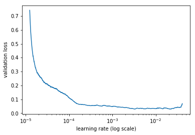

```python
m.sched.plot(100)
```

So, in this case, we've chose 1e-3 for the learning rate.

```python
m = md.get_learner(emb_szs, len(df.columns)-len(cat_vars),
                   0.04, 1, [1000,500], [0.001,0.01], y_range=y_range)
lr = 1e-3
```

Now, this is where we train the model. We'll start off by training one epoch to see how the loss function looks

```python
m.fit(lr, 1, metrics = [exp_rmspe])
```

```
epoch      trn_loss   val_loss   exp_rmspe
    0      0.014479   0.014716   0.123548
```

```
[array([0.01472]), 0.12354795337722888]
```

Run for another 3 epochs to see if it gets any better.

```python
m.fit(lr, 3, metrics = [exp_rmspe])
```

```
epoch      trn_loss   val_loss   exp_rmspe
    0      0.010949   0.012182   0.107549
    1      0.010039   0.013033   0.118676
    2      0.009683   0.012391   0.11529
```

```
[array([0.01239]), 0.11529007518685357]
```

We'll now apply an interesting made available in the fastai library, stochastic gradient descent with restarts (SGDR). The goal of alogrithm is to vary the learning every cycle (set to 1 epoch) by reducing the learning rate (learning rate annealing) which is a very common learning technique, here we use one half of the cosine function. This will force the model to find a stable and accurate area in the weight space. By resetting the learning rate, the model will jump to different space if its in a "spiky" area in the weight space.

```python
m.fit(lr,3,cycle_len=1,metrics = [exp_rmspe])
```

```
epoch      trn_loss   val_loss   exp_rmspe
    0      0.007312   0.010269   0.102628
    1      0.007089   0.009939   0.100868
    2      0.007235   0.009707   0.099116
```

```
[array([0.00971]), 0.09911566070467134]
```

This is the plot of the learning rate adjustments per cycle.

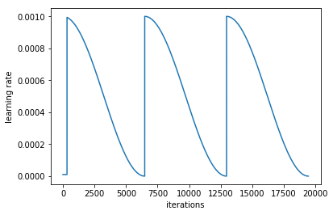

```python
m.sched.plot_lr()
```

#### Test

```python
x,y=m.predict_with_targs()
```

```python
exp_rmspe(x,y)
```

[output not shown]

```python
pred_test=m.predict(True)
```

```python
pred_test=np.exp(pred_test)
```

```python
joined_test['Sales'] = pred_test
```

```python
csv_fn = f'{PATH}tmp/sub.csv'
```

```python
joined_testt[['Id', 'Sales']].to_csv(csv_fn, index=False)
```

```python
FileLink(csv_fn)
```